# Lab 5

Cameron Stocker and Tyler Kruzan

11/12/2019

### 1

```r
diabetes = read.table("diabetes.txt", header = TRUE)
str(diabetes)
```

```
## 'data.frame':    403 obs. of  19 variables:
##  $ id      : int  1000 1001 1002 1003 1005 1008 1011 1015 1016 1022 ...
##  $ chol    : int  203 165 228 78 249 248 195 227 177 263 ...
##  $ stab.glu: int  82 97 92 93 90 94 92 75 87 89 ...
##  $ hdl     : int  56 24 37 12 28 69 41 44 49 40 ...
##  $ ratio   : num  3.6 6.9 6.2 6.5 8.9 ...
##  $ glyhb   : num  4.31 4.44 4.64 4.63 7.72 ...
##  $ location: Factor w/ 2 levels "Buckingham","Louisa": 1 1 1 1 1 1 1 1 1 1 ...
##  $ age     : int  46 29 58 67 64 34 30 37 45 55 ...
##  $ gender  : Factor w/ 2 levels "female","male": 1 1 1 2 2 2 2 2 2 1 ...
##  $ height  : int  62 64 61 67 68 71 69 59 69 63 ...
##  $ weight  : int  121 218 256 119 183 190 191 170 166 202 ...
##  $ frame   : Factor w/ 4 levels "","large","medium",..: 3 2 2 2 3 2 3 3 2 4 ...
##  $ bp.1s   : int  118 112 190 110 138 132 161 NA 160 108 ...
##  $ bp.1d   : int  59 68 92 50 80 86 112 NA 80 72 ...
##  $ bp.2s   : int  NA NA 185 NA NA NA 161 NA 128 NA ...
##  $ bp.2d   : int  NA NA 92 NA NA NA 112 NA 86 NA ...
##  $ waist   : int  29 46 49 33 44 36 46 34 34 45 ...
##  $ hip     : int  38 48 57 38 41 42 49 39 40 50 ...
##  $ time.ppn: int  720 360 180 480 300 195 720 1020 300 240 ...
```

### 2

```r
diabetes[which(diabetes$frame == ''), 'frame'] = NA
diabetes$frame = droplevels(diabetes$frame)
```

### 3

```r
diabetes_reduced = select(diabetes, -id, -bp.2s, -bp.2d)
```

### 4

```r
diabetes_clean = diabetes_reduced[complete.cases(diabetes_reduced),]
```

### 5

```r
summary(diabetes_clean)
```

```
##       chol          stab.glu          hdl             ratio
##  Min.   : 78.0   Min.   : 48.0   Min.   : 12.00   Min.   : 1.500
##  1st Qu.:179.0   1st Qu.: 81.0   1st Qu.: 38.00   1st Qu.: 3.200
##  Median :203.5   Median : 90.0   Median : 46.00   Median : 4.200
##  Mean   :207.5   Mean   :107.4   Mean   : 50.27   Mean   : 4.536
##  3rd Qu.:228.8   3rd Qu.:108.0   3rd Qu.: 59.00   3rd Qu.: 5.400
##  Max.   :443.0   Max.   :385.0   Max.   :120.00   Max.   :19.300
##      glyhb              location        age           gender
##  Min.   : 2.680   Buckingham:175   Min.   :19.00   female:214
##  1st Qu.: 4.393   Louisa    :191   1st Qu.:34.00   male  :152
##  Median : 4.860                    Median :45.00
##  Mean   : 5.607                    Mean   :46.69
##  3rd Qu.: 5.630                    3rd Qu.:60.00
##  Max.   :16.110                    Max.   :92.00
##      height          weight         frame         bp.1s
##  Min.   :52.00   Min.   : 99.0   large : 96   Min.   : 90.0
##  1st Qu.:63.00   1st Qu.:151.0   medium:172   1st Qu.:121.2
##  Median :66.00   Median :174.0   small : 98   Median :136.0
##  Mean   :66.05   Mean   :178.1                Mean   :137.2
##  3rd Qu.:69.00   3rd Qu.:200.0                3rd Qu.:148.0
##  Max.   :76.00   Max.   :325.0                Max.   :250.0
##      bp.1d            waist            hip           time.ppn
##  Min.   : 48.00   Min.   :26.00   Min.   :30.00   Min.   :   5.00
##  1st Qu.: 75.00   1st Qu.:33.00   1st Qu.:39.00   1st Qu.:  93.75
##  Median : 82.00   Median :37.00   Median :42.00   Median : 240.00
##  Mean   : 83.36   Mean   :37.93   Mean   :43.05   Mean   : 339.04
##  3rd Qu.: 92.00   3rd Qu.:41.75   3rd Qu.:46.00   3rd Qu.: 480.00
##  Max.   :124.00   Max.   :56.00   Max.   :64.00   Max.   :1560.00
```

You can see that Step 4 was completed correctly beause summary does not show any NA values.

### 6 & 7

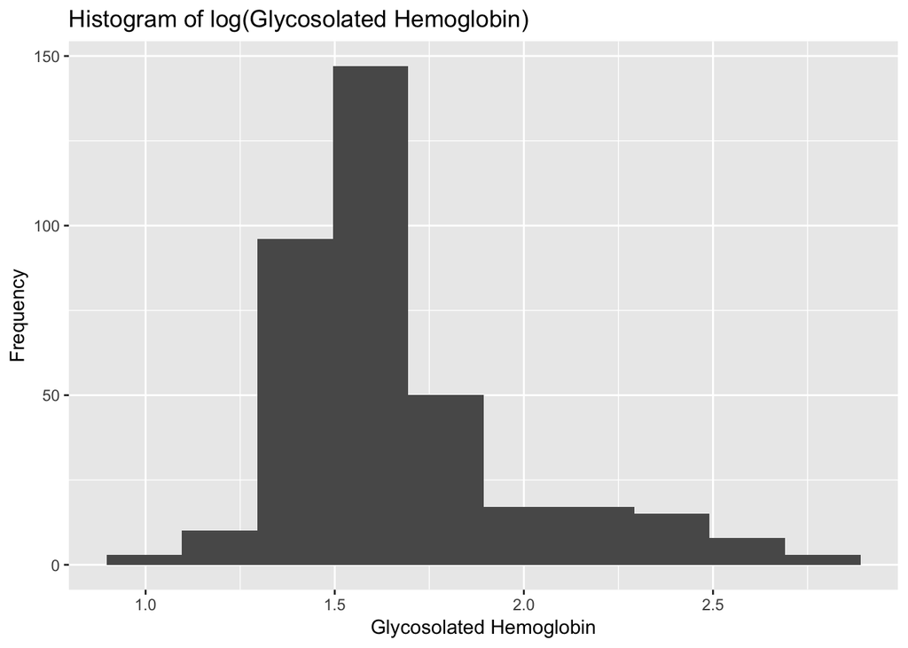

```r
diabetes_clean = mutate(diabetes_clean, glyhb_star = log(glyhb))
ggplot(diabetes_clean, aes(glyhb_star)) + geom_histogram(bins = 10) + labs(x = "Glycosolated Hemoglobin", y= "Frequency", title = "Histogram of log(Glycosolated Hemoglobin)")
```

We have used a log transformation on the dataset. It is a relatively strong transformation which makes its interpretability harder. However, the transformation works because the graph is less right skewed. If you account for less bins, the distribution appears to much more normal.

### 8

```r
diabetes_clean %>% group_by(frame) %>% summarise(mean.glyhb = mean(glyhb_star))
```

```
## # A tibble: 3 x 2
##   frame  mean.glyhb
##   <fct>       <dbl>
## 1 large        1.75
## 2 medium       1.67
## 3 small        1.58
```

```r
diabetes_clean %>% group_by(waist) %>% summarise(mean.glyhb = mean(glyhb_star))
```

```
## # A tibble: 29 x 2
##    waist mean.glyhb
##    <int>      <dbl>
##  1    26       1.32
##  2    28       1.40
##  3    29       1.54
##  4    30       1.44
##  5    31       1.51
##  6    32       1.49
##  7    33       1.63
##  8    34       1.68
##  9    35       1.66
## 10    36       1.72
## # … with 19 more rows
```

```r
diabetes_clean %>% group_by(height) %>% summarise(mean.glyhb = mean(glyhb_star))
```

```
## # A tibble: 21 x 2
##    height mean.glyhb
##     <int>      <dbl>
##  1     52       1.45
##  2     55       1.57
##  3     58       1.58
##  4     59       1.85
##  5     60       1.74
##  6     61       1.68
##  7     62       1.66
##  8     63       1.66
##  9     64       1.54
## 10     65       1.66
## # … with 11 more rows
```

```r
diabetes_clean %>% group_by(location) %>% summarise(mean.glyhb = mean(glyhb_star))
```

```
## # A tibble: 2 x 2
##   location   mean.glyhb
##   <fct>           <dbl>
## 1 Buckingham       1.69
## 2 Louisa           1.65
```

```r
diabetes_clean %>% group_by(gender) %>% summarise(mean.glyhb = mean(glyhb_star))
```

```
## # A tibble: 2 x 2
##   gender mean.glyhb
##   <fct>       <dbl>
## 1 female       1.65
## 2 male         1.69
```

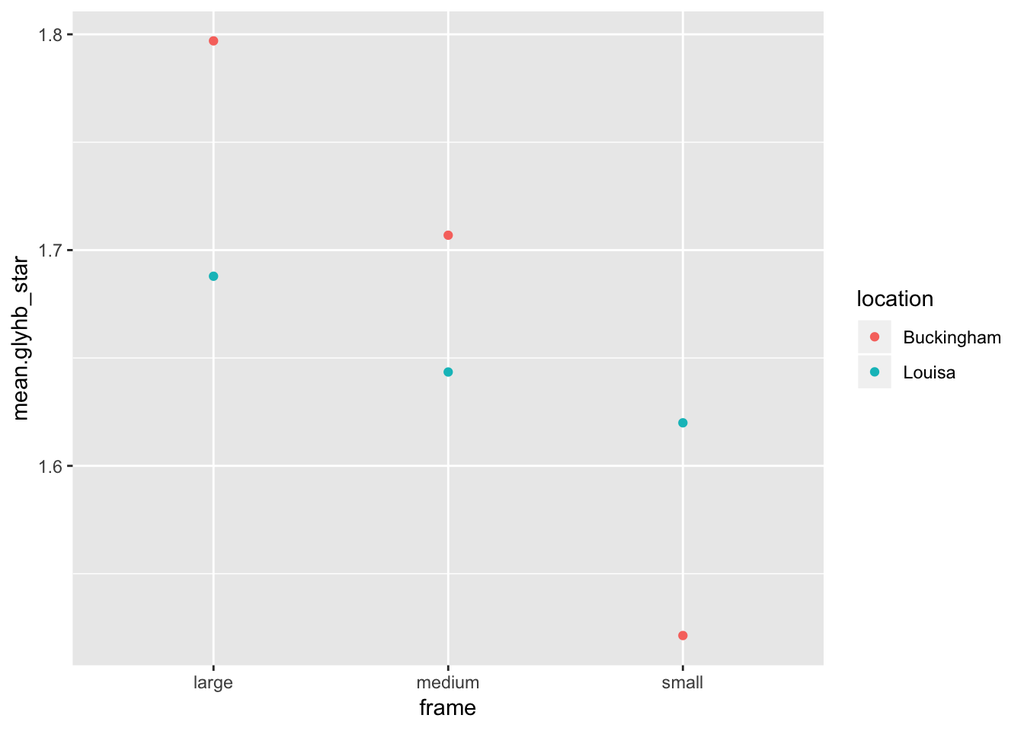

```r
diabetes_clean %>% group_by(frame, location) %>% summarise(mean.glyhb_star=mean(glyhb_star)) %>%
  ggplot(aes(x = frame, y = mean.glyhb_star, color=location))+
  geom_point()
```

### 11

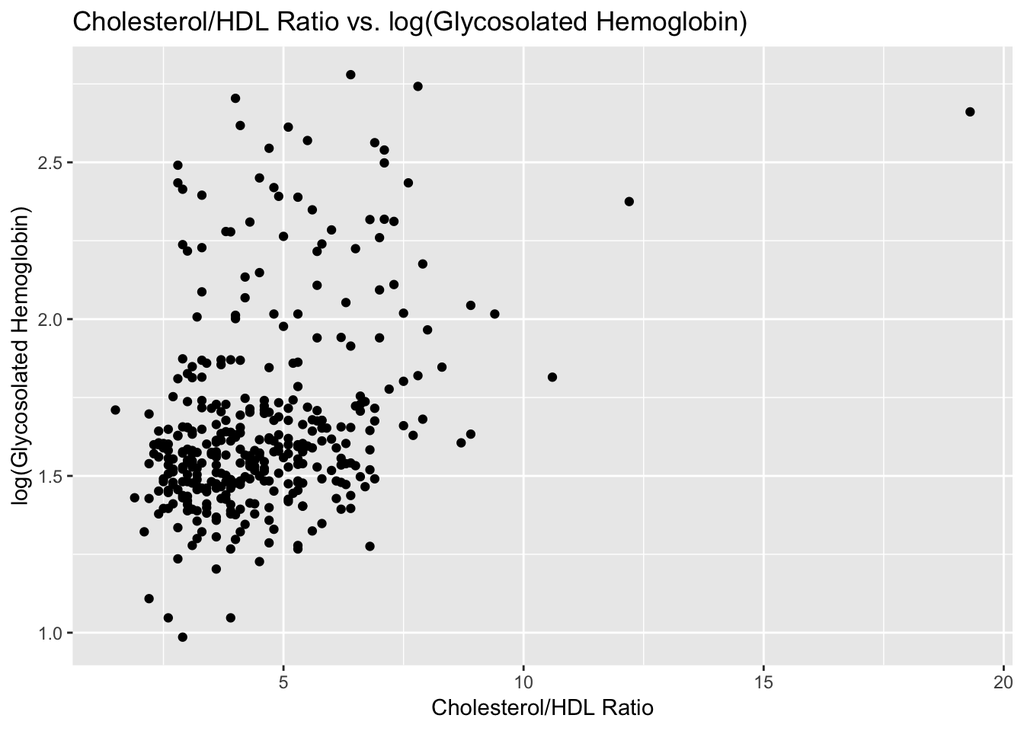

```r
ggplot(diabetes_clean, aes(ratio, glyhb_star)) + geom_point() + labs(x = "Cholesterol/HDL Ratio", y = "log(Glycosolated Hemoglobin)", title = "Cholesterol/HDL Ratio vs. log(Glycosolated Hemoglobin)")
```

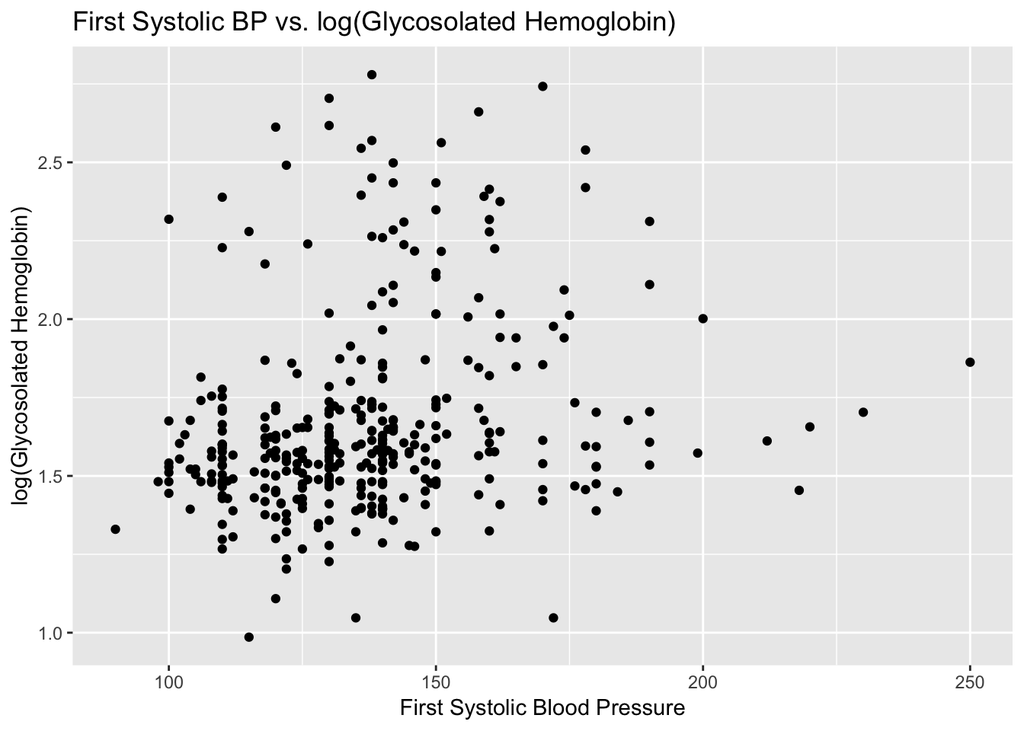

```r
ggplot(diabetes_clean, aes(bp.1s, glyhb_star)) + geom_point() + labs(x = "First Systolic Blood Pressure", y = "log(Glycosolated Hemoglobin)", title = "First Systolic BP vs. log(Glycosolated Hemoglobin)")
```

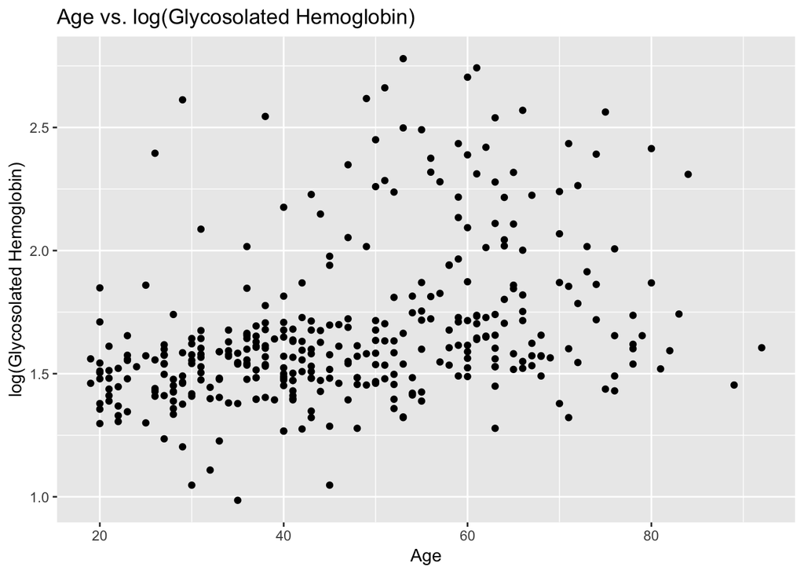

```r
ggplot(diabetes_clean, aes(age, glyhb_star)) + geom_point() + labs(x = "Age", y = "log(Glycosolated Hemoglobin)", title = "Age vs. log(Glycosolated Hemoglobin)")
```

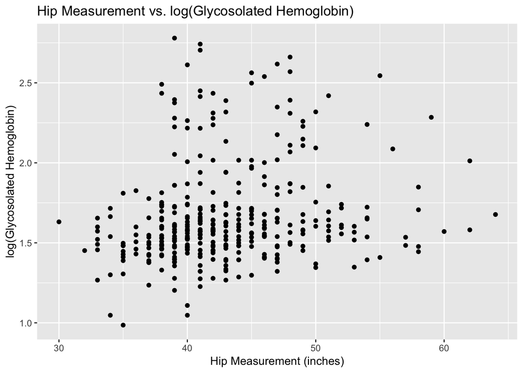

```r
ggplot(diabetes_clean, aes(hip, glyhb_star)) + geom_point() + labs(x = "Hip Measurement (inches)", y = "log(Glycosolated Hemoglobin)", title = "Hip Measurement vs. log(Glycosolated Hemoglobin)")
```

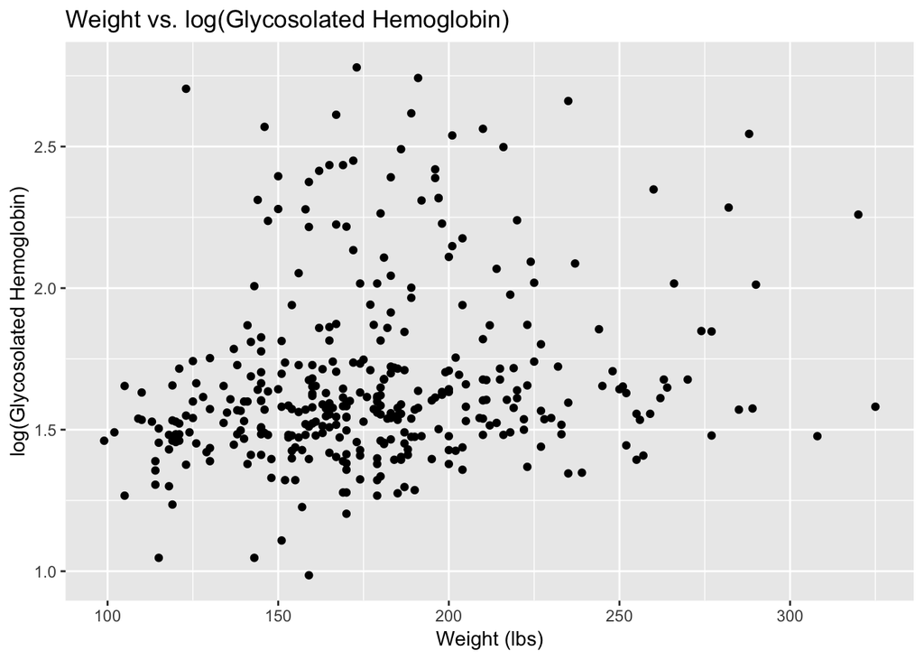

```r
ggplot(diabetes_clean, aes(weight, glyhb_star)) + geom_point() + labs(x = "Weight (lbs)", y = "log(Glycosolated Hemoglobin)", title = "Weight vs. log(Glycosolated Hemoglobin)")
```

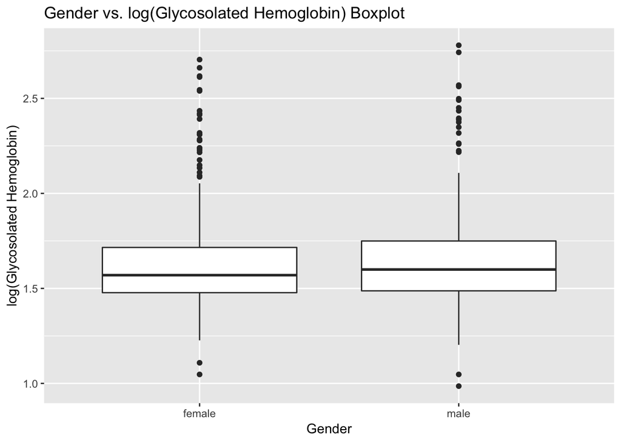

```r
ggplot(diabetes_clean, aes(x = gender, y = glyhb_star)) + geom_boxplot() + labs(x = "Gender", y = "log(Glycosolated Hemoglobin)", title = "Gender vs. log(Glycosolated Hemoglobin) Boxplot")
```

### 12

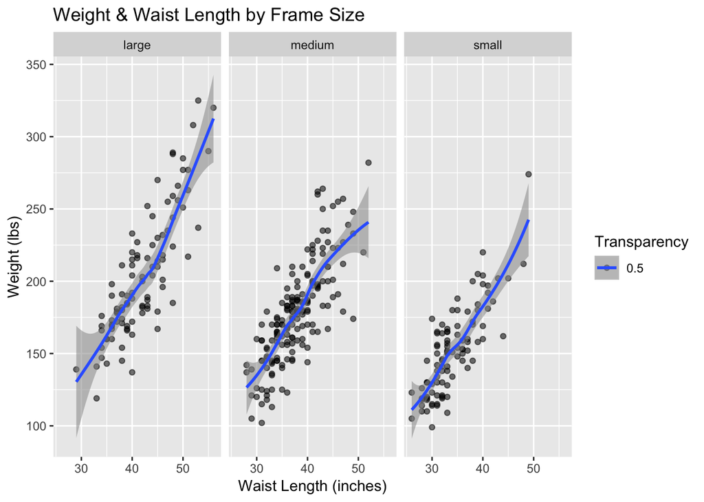

```r
ggplot(diabetes_clean,aes(y=weight,x=waist,alpha=0.5)) + geom_point() +  facet_wrap(~frame)+ geom_smooth() +labs(title = "Weight & Waist Length by Frame Size", x = "Waist Length (inches)", y = "Weight (lbs)", alpha= "Transparency")
```

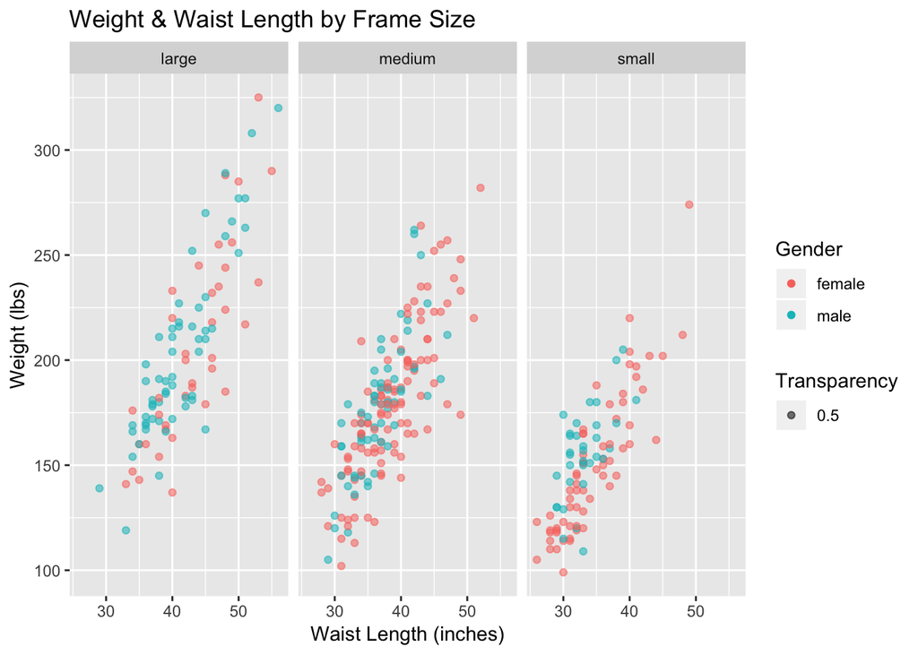

```r
ggplot(diabetes_clean,aes(y=weight,x=waist,alpha=0.5)) + geom_point(aes(color = diabetes_clean$gender)) + facet_wrap(~frame) +labs(title = "Weight & Waist Length by Frame Size", x = "Waist Length (inches)", y = "Weight (lbs)",color='Gender', alpha= "Transparency")
```

When visualizing the graphs above, we did not find any issues with overplotting. We added color and a smoothing line to create better insights for the relationship between the different frame sizes and the relationship between `frame` and `gender`

### 13

The `gather` function takes multiple columns that should be values of a variables and converts them into 2 columns: key and value. Where the key is the name of the column for the new variable that has the values that you are wanting to transform and the value is the value of that variable that you are wanting to `gather`.

The `spread` function is the inverse of that as it is used when there is a column that contains values that should be variable headers instead.

### 14

`gather` & `spread` are not exact complements of each other, in fact they are opposites of each other. `spread` turns a key-value pair into a set of tidy-columns. `gather` turns a set of column names into a single key column.

### 15

```r
fit = lm(glyhb_star ~ stab.glu + age + waist + ratio + factor(frame), data = diabetes_clean)
summary(fit)
```

```
##
## Call:
## lm(formula = glyhb_star ~ stab.glu + age + waist + ratio + factor(frame),
##     data = diabetes_clean)
##
## Residuals:
##     Min      1Q  Median      3Q     Max
## -1.0548 -0.1176 -0.0123  0.1020  1.0613
##
## Coefficients:
##                      Estimate Std. Error t value Pr(>|t|)
## (Intercept)         0.8330897  0.0984743   8.460 6.86e-16 ***
## stab.glu            0.0035182  0.0002200  15.992  < 2e-16 ***
## age                 0.0033632  0.0007144   4.708 3.58e-06 ***
## waist               0.0047925  0.0022352   2.144  0.03270 *
## ratio               0.0219341  0.0068169   3.218  0.00141 **
## factor(frame)medium 0.0309167  0.0283657   1.090  0.27648
## factor(frame)small  0.0131840  0.0351518   0.375  0.70784
## ---
## Signif. codes:  0 '***' 0.001 '**' 0.01 '*' 0.05 '.' 0.1 ' ' 1
##
## Residual standard error: 0.2085 on 359 degrees of freedom
## Multiple R-squared:  0.5643, Adjusted R-squared:  0.557
## F-statistic: 77.49 on 6 and 359 DF,  p-value: < 2.2e-16
```

We can see that this model has a significant relationship with the log of `glyhb`. We know this because we have a large F-statistic of 77.49 with a small p-value of <2.2e-16, which is less than any reasonable alpha. The adjusted r-squared tells us that 55.7% of the variation in the log of `glyhb` can be explained by this model.

### 16

B0 = 0.8331: estimate of the mean value of log of glycosolated hemoglobin when stabilized glucose, age, waist, and cholesterol/HDL ratio are equal to 0 and the frame is large.

B1 = 0.0035: estimate of the change in the mean of log of glycosolated hemoglobin when stabilized glucose increases by 1 unit, holding all other covariates constant.

B2 = 0.0034: estimate of the change in the mean of log of glycosolated hemoglobin when age increases by 1 year, holding all other covariates constant.

B3 = 0.0048: estimate of the change in the mean of log of glycosolated hemoglobin when waist increases by 1 inches, holding all other covariates constant.

B4 = 0.0219: estimate of the change in the mean of log of glycosolated hemoglobin when Cholesterol/HDL ratio increases by 1 unit, holding all other covariates constant.

B5 = 0.0309: estimate of the difference in the predicted glycosolated hemoglobin when frame is medium instead of large, holding all other covariates constant.

B6 = 0.0132: estimate of the difference in the predicted glycosolated hemoglobin when frame is small instead of large, holding all other covariates constant.

### 17

```r
newdiabetes = data.frame(stab.glu=90, age=35,waist=30,ratio=5.1,frame="small")
predict.lm(fit, newdiabetes, interval = "prediction")
```

```
##       fit      lwr      upr
## 1 1.53626 1.123012 1.949508
```

### 18

Inferences are conclusions based on facts or evidence about something in the present. An example would be that if `weight` and `glyhb` have a positive relationship, then you would deduce or infer that as `weight` increases so does `glyhb`. If you see a bunch of people wearing winter coats, you could infer that it is cold outside.

Predictions are conclusions based on facts or evidence about something that will or may happen in the future. An example would be that if there is a low pressure & high pressure system in the Ames area, you could predict that there may be a tornado tomorrow.

### 19

**Pros of Linear Regression over KNN Regression**

Linear Regression will create a “shape” for the data because it is parametric. Parametric models are easier to interpret. Relatively quick compared to KNN regression.

**Cons of Linear Regression over KNN Regression**

The data cannot actually speak for itself, because we don’t really know if the assumptions we made are true. Linear regression has the common problem of overfitting.

### 20

**Most surprising parts of Data Science:**

One of the main things that was truly surprising about Data Science has been the amount of prep work that goes into cleaning and tidying data. Before you can make analysis and give insights about the data you are working with, you must first make it workable. Learning about the various different packages supported by R for visualization has opened our mind about new ways that data can be visualized.

**Most challenging parts of Data Science:**

Something that has been a little bit hard has been collaboration. You can collaborate with people via the internet, like getting help from StackOverflow, Reddit, or Piazza. However, in terms of real time collaboration with a team or partner is still tough because you must be in direct communication with the group before you push or pull your work to Github. Additionally, thinking outside of the box has proved to be a very valuable trait when working with data that seems elementary or dry.

**Most enjoyable parts of Data Science:**

We believe that there is a moment where you can feel that you have transformed data into information. This moment is the reason why data scientists are in such high demand and we can give insights that somebody without a data science would not be able to achieve. Being able to explain things and teach people about various subjects using data is very empowering in our modern society where more than 2.5 quintillion bytes of data are collected everyday.

**Owner Github Username: CameronStocker** **Partner Github Username: tkruzan** **Repo Name: ds202_lab5**